# Team 6 Project 2

Maximos Nolan, Gloria Stach, Jack Yu, Neo Li, Zihan Zeng

2022-12-04

# Dataset Introduction

Our dataset, “Hotel Booking Demand” is obtained from Kaggle (https://www.kaggle.com/datasets/jessemostipak/hotel-booking-demand?page=2) and contains booking information for a city hotel and a resort hotel for a full year. The following variables are recorded in the dataset.

- **Hotel**, H1 = Resort Hotel or H2 = City Hotel)
- **Is_canceled**, value indicating if the booking was canceled (1) or not (0)
- **Lead_time**, number of days that elapsed between the entering date of the booking into the PMS and the arrival date
- **Arrival_date_year**, year of arrival date
- **Arrival_date_month**, month of arrival date
- **Arrival_date_week_number**, week number of year for arrival date
- **Arrival_date_day_of_month**, day of arrival date
- **Stays_in_weekend_nights**, number of weekend nights (Saturday or Sunday) the guest stayed or booked to stay at the hotel
- **Stays_in_week_nights**, number of week nights (Monday to Friday) the guest stayed or booked to stay at the hotel
- **Adults**, number of adults
- **Children**, number of children
- **Babies**, number of babies
- **Meal**, type of meal booked
- **Country**, country of origin
- **Market_segment**, market segment designation
- **Distribution_channel**, booking distribution channel
- **Is_repeated_guest**, value indicating if the booking name was from a repeated guest (1) or not (0)
- **Previous_cancellations**, number of previous bookings that were cancelled by the customer prior to the current booking
- **Previous_bookings_not_canceled**, number of previous bookings not cancelled by the customer prior to the current booking
- **Reserved_room_type**, code of room type reserved
- **Assigned_room_type**, code for the type of room assigned to the booking
- **Booking_changes**, number of changes/amendments made to the booking from the moment the booking was entered on the PMS until the moment of check-in or cancellation
- **Deposit_type**, indication on if the customer made a deposit to guarantee the booking
- **Agent**, ID of the travel agency that made the booking
- **Company**, ID of the company/entity that made the booking or responsible for paying the booking
- **Days_in_waiting_list**, number of days the booking was in the waiting list before it was confirmed to the customer
- **Customer_type**, type of booking, assuming one of four categories: Contract, Group, Transient, and Transient-party
- **Adr**, average Daily Rate as defined by dividing the sum of all lodging transactions by the total number of staying nights
- **Required_car_parking_spaces**, number of car parking spaces required by the customer
- **Total_of_special_requests**, number of special requests made by the customer
- **Reservation_status**, reservation last status, assuming one of three categories: Canceled – booking was canceled by the customer; Check-Out – customer has checked in but already departed; No-Show – customer did not check-in and did inform the hotel of the reason why
- **Reservation_status_date**, date at which the last status was set

# Business Question

Monitoring the rate of cancellation is important for every hotel as it’s related to its revenue. We know that customers have different willingness to pay when they book the hotels at different dates. When they book ahead of time, they are more price sensitive, and the hotels normally charge a normal price. But for the customers who arrive on the day of booking, they have more inelastic demand and thus are willing to pay more. Therefore, hotels would charge them a premium. In order to have rooms for these “pay upon arrival” customers, hotel management needs to have rooms reserved for them or protection levels, similar to the concept of safety stock in supply chain management.

Cancellations is one important part of calculating the protection levels, as booking cancellations on the day of arrival means more rooms for customers who are willing to pay a premium. Thus hotels factor in the rate of cancellation in their planning. **Now let’s assume the hotel is operating with just enough rooms to meet the “pay upon arrival” demand by including reserved rooms and expected cancelled normal price rooms.** Then random cancellations would mess up the planning as the empty room will be unused. Thus the hotels would need to weight the benefit and cost of having cancellations, with the simplest approach being calculating an average percentage of cancellations among all customers. How can we improve this approach to have more confidence in the rooms planning process?

The business question is thus how can we construct a model to predict a customer’s rate of cancellation and plan the protection level accordingly to maximize the operating profit?

To see the impact of cancellation, we have two scenarios:

- The customer is predicted to not cancel but actually has a cancellation: since the demand for premium price is already met, this additional empty room will be unoccupied, thus generating a loss equals to the normal price.
- The customer is predicted to cancel but does not cancel: since we expect the customer to cancel, we expect to have one additional room for the higher willingness to pay customer groups. But not the customer doesn’t cancel, so we lose a prospect revenue of premium price - normal price.

Thus we can further refine our question to be, how can we construct a model to predict a customer’s rate of cancellation and plan the protection level accordingly to minimize the revenue loss from cancellations and therefore maximize the operating profit?

# Load the required library

```r
library(gmodels)
library(ggplot2)
library(caret)
library(neuralnet)
library(tidyverse)
library(class)
library(dplyr)
library(C50)
library(kernlab)
library(e1071)
```

# Load the required dataset

```r
# Load data
hoteldata <- read.csv("hotel_bookings.csv")
# View data
summary(hoteldata)
```

```
##     hotel            is_canceled       lead_time   arrival_date_year
##  Length:119390      Min.   :0.0000   Min.   :  0   Min.   :2015
##  Class :character   1st Qu.:0.0000   1st Qu.: 18   1st Qu.:2016
##  Mode  :character   Median :0.0000   Median : 69   Median :2016
##                     Mean   :0.3704   Mean   :104   Mean   :2016
##                     3rd Qu.:1.0000   3rd Qu.:160   3rd Qu.:2017
##                     Max.   :1.0000   Max.   :737   Max.   :2017
##
##  arrival_date_month arrival_date_week_number arrival_date_day_of_month
##  Length:119390      Min.   : 1.00            Min.   : 1.0
##  Class :character   1st Qu.:16.00            1st Qu.: 8.0
##  Mode  :character   Median :28.00            Median :16.0
##                     Mean   :27.17            Mean   :15.8
##                     3rd Qu.:38.00            3rd Qu.:23.0
##                     Max.   :53.00            Max.   :31.0
##
##  stays_in_weekend_nights stays_in_week_nights     adults
##  Min.   : 0.0000         Min.   : 0.0         Min.   : 0.000
##  1st Qu.: 0.0000         1st Qu.: 1.0         1st Qu.: 2.000
##  Median : 1.0000         Median : 2.0         Median : 2.000
##  Mean   : 0.9276         Mean   : 2.5         Mean   : 1.856
##  3rd Qu.: 2.0000         3rd Qu.: 3.0         3rd Qu.: 2.000
##  Max.   :19.0000         Max.   :50.0         Max.   :55.000
##
##     children           babies              meal             country
##  Min.   : 0.0000   Min.   : 0.000000   Length:119390      Length:119390
##  1st Qu.: 0.0000   1st Qu.: 0.000000   Class :character   Class :character
##  Median : 0.0000   Median : 0.000000   Mode  :character   Mode  :character
##  Mean   : 0.1039   Mean   : 0.007949
##  3rd Qu.: 0.0000   3rd Qu.: 0.000000
##  Max.   :10.0000   Max.   :10.000000
##  NA's   :4
##  market_segment     distribution_channel is_repeated_guest
##  Length:119390      Length:119390        Min.   :0.00000
##  Class :character   Class :character     1st Qu.:0.00000
##  Mode  :character   Mode  :character     Median :0.00000
##                                          Mean   :0.03191
##                                          3rd Qu.:0.00000
##                                          Max.   :1.00000
##
```

[output cut: 25 more lines]

```
##  Min.   :0.00000             Min.   :0.0000            Length:119390
##  1st Qu.:0.00000             1st Qu.:0.0000            Class :character
##  Median :0.00000             Median :0.0000            Mode  :character
##  Mean   :0.06252             Mean   :0.5714
##  3rd Qu.:0.00000             3rd Qu.:1.0000
##  Max.   :8.00000             Max.   :5.0000
##
##  reservation_status_date
##  Length:119390
##  Class :character
##  Mode  :character
##
##
##
##
```

```r
str(hoteldata)
```

```
## 'data.frame':    119390 obs. of  32 variables:
##  $ hotel                         : chr  "Resort Hotel" "Resort Hotel" "Resort Hotel" "Resort Hotel" ...
##  $ is_canceled                   : int  0 0 0 0 0 0 0 0 1 1 ...
##  $ lead_time                     : int  342 737 7 13 14 14 0 9 85 75 ...
##  $ arrival_date_year             : int  2015 2015 2015 2015 2015 2015 2015 2015 2015 2015 ...
##  $ arrival_date_month            : chr  "July" "July" "July" "July" ...
##  $ arrival_date_week_number      : int  27 27 27 27 27 27 27 27 27 27 ...
##  $ arrival_date_day_of_month     : int  1 1 1 1 1 1 1 1 1 1 ...
##  $ stays_in_weekend_nights       : int  0 0 0 0 0 0 0 0 0 0 ...
##  $ stays_in_week_nights          : int  0 0 1 1 2 2 2 2 3 3 ...
##  $ adults                        : int  2 2 1 1 2 2 2 2 2 2 ...
##  $ children                      : int  0 0 0 0 0 0 0 0 0 0 ...
##  $ babies                        : int  0 0 0 0 0 0 0 0 0 0 ...
##  $ meal                          : chr  "BB" "BB" "BB" "BB" ...
##  $ country                       : chr  "PRT" "PRT" "GBR" "GBR" ...
```

[output cut: 18 more lines]

```r
# Store the original data set to a new one
hotel_data_initial = hoteldata
```

# Explore the dataset by visualization

**Through our life experience, we start by exploring some variables first that could potentially impact the cancellation rate**

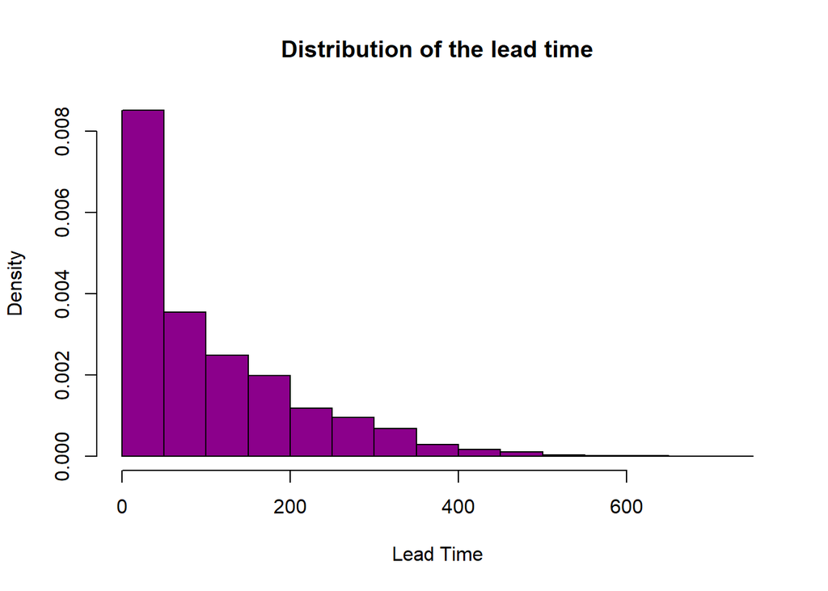

```r
# Check the lead_time
hist(hoteldata$lead_time, main="Distribution of the lead time", xlab="Lead Time",col="darkmagenta",
freq=FALSE)
```

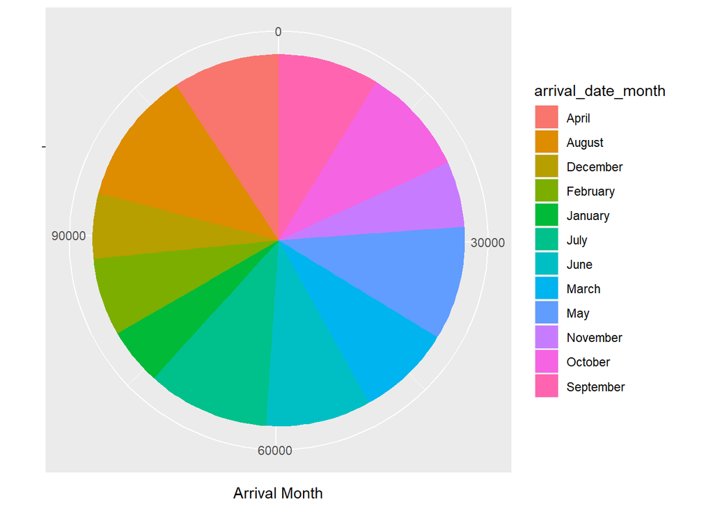

```r
# Check the customers' arrival month
ggplot(hoteldata) + geom_bar(mapping = aes(x = "", fill = arrival_date_month)) + labs(x = NULL) + coord_polar(theta = "y") + ylab("Arrival Month")
```

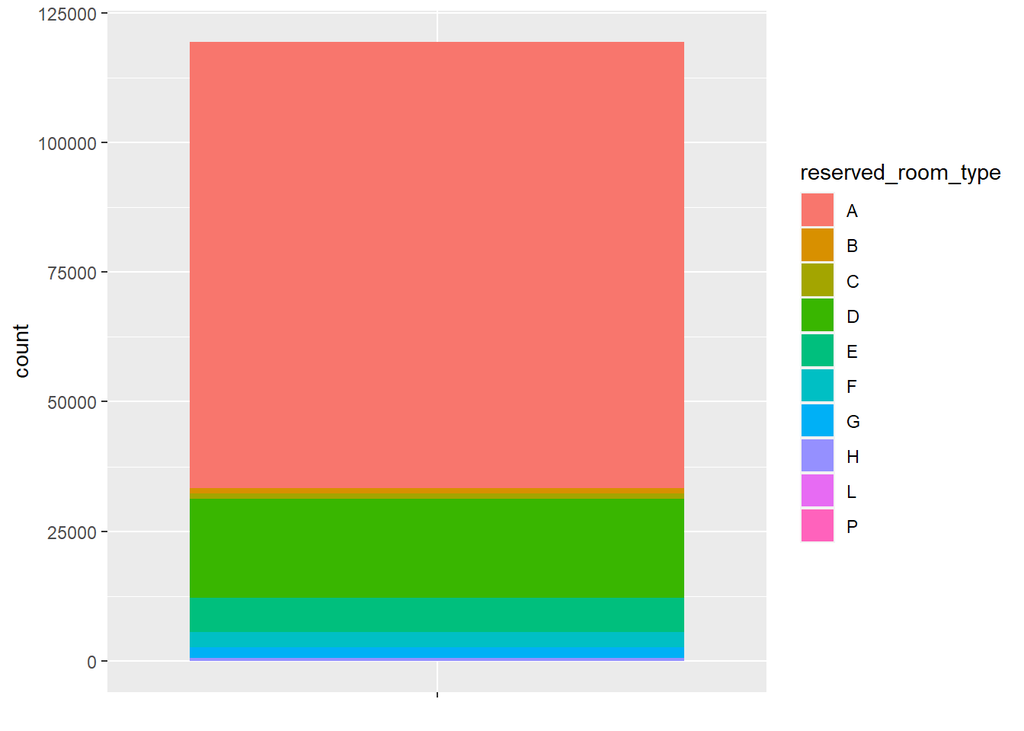

```r
# Check the reserved room type
ggplot(hoteldata) + geom_bar(mapping = aes(x = "", fill = reserved_room_type)) + labs(x = NULL)
```

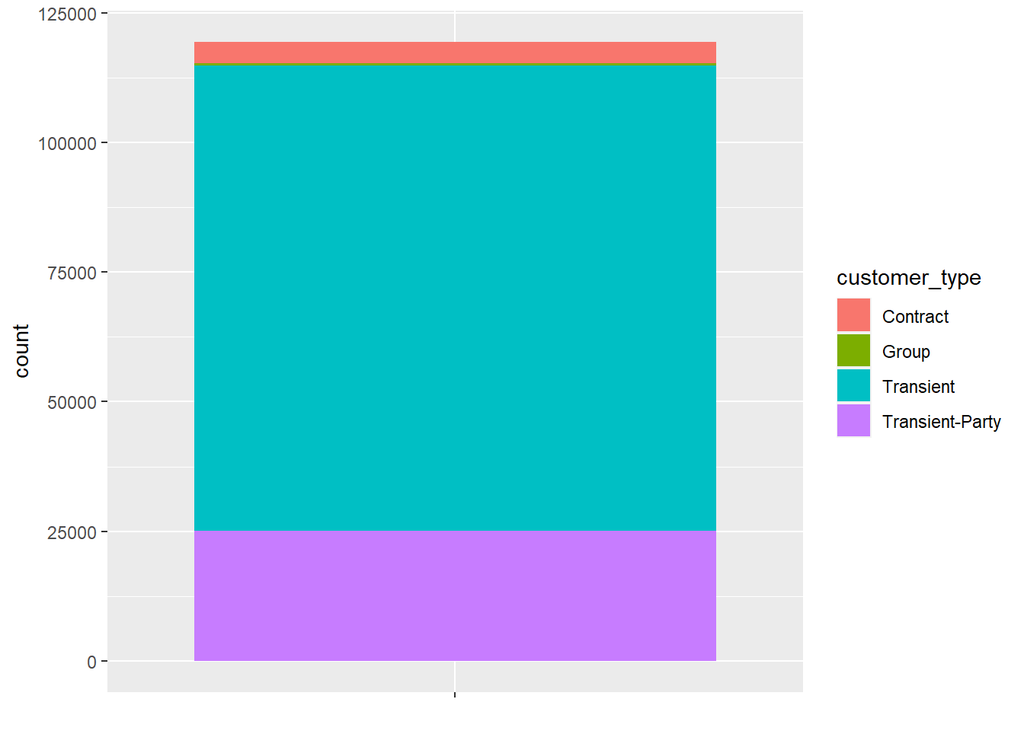

```r
# Check the customer type
ggplot(hoteldata) + geom_bar(mapping = aes(x = "", fill = customer_type)) + labs(x = NULL)
```

```r
# Check the reserved room type, grouped by country
hoteldata1 = hoteldata %>% group_by(reserved_room_type, country) %>% summarize(market_segment, country, n = n()) %>% distinct
```

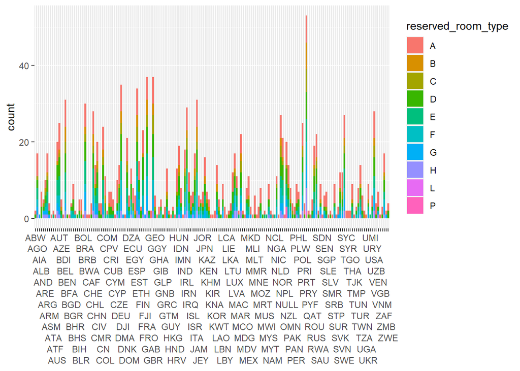

```r
ggplot(hoteldata1) + geom_bar(mapping = aes(x = country, fill = reserved_room_type)) + labs(x = NULL) + scale_x_discrete(guide = guide_axis(n.dodge = 12))
```

```r
# Check the customer type, grouped by country
hoteldata2 = hoteldata %>% group_by(customer_type, country) %>% summarize(customer_type, country, n = n()) %>% distinct
```

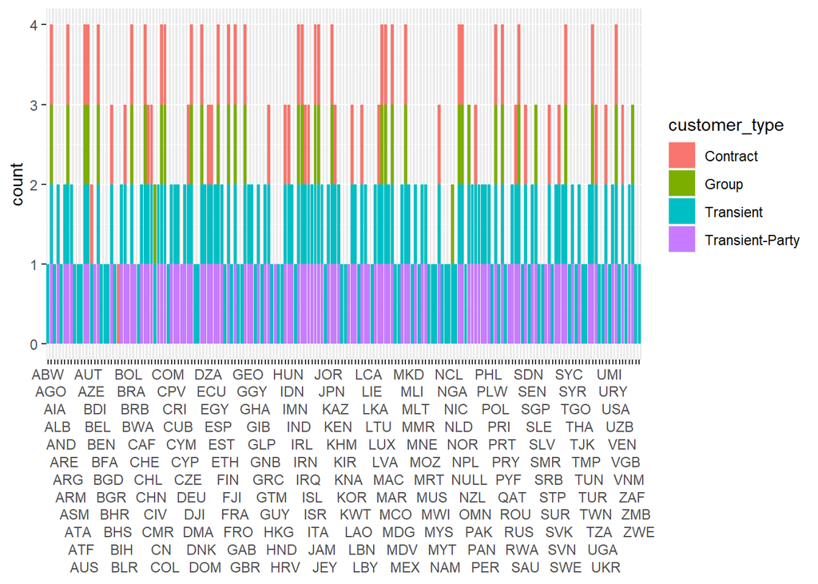

```r
ggplot(hoteldata2) + geom_bar(mapping = aes(x = country, fill = customer_type)) + labs(x = NULL) + scale_x_discrete(guide = guide_axis(n.dodge = 12))
```

**Visualization Briefing** We can see the distribution of lead time is skewed to the right, and the majority of customers book the rooms prior to 200 days of arrival. The arrival date month is roughly equally distributed between the twelve months. The most reserved room type is type A, with type D being second popular. Customer type is mainly transient and seconded by transient-party.

When combined with country-based analysis, we can find that the total number of country type is too large, thus making the graph fuzzy. We may need to take care of the “country” variable later.

# Clean the dataset

```r
# Check that data
summary(hoteldata)
```

```
##     hotel            is_canceled       lead_time   arrival_date_year
##  Length:119390      Min.   :0.0000   Min.   :  0   Min.   :2015
##  Class :character   1st Qu.:0.0000   1st Qu.: 18   1st Qu.:2016
##  Mode  :character   Median :0.0000   Median : 69   Median :2016
##                     Mean   :0.3704   Mean   :104   Mean   :2016
##                     3rd Qu.:1.0000   3rd Qu.:160   3rd Qu.:2017
##                     Max.   :1.0000   Max.   :737   Max.   :2017
##
##  arrival_date_month arrival_date_week_number arrival_date_day_of_month
##  Length:119390      Min.   : 1.00            Min.   : 1.0
##  Class :character   1st Qu.:16.00            1st Qu.: 8.0
##  Mode  :character   Median :28.00            Median :16.0
##                     Mean   :27.17            Mean   :15.8
##                     3rd Qu.:38.00            3rd Qu.:23.0
##                     Max.   :53.00            Max.   :31.0
##
##  stays_in_weekend_nights stays_in_week_nights     adults
##  Min.   : 0.0000         Min.   : 0.0         Min.   : 0.000
##  1st Qu.: 0.0000         1st Qu.: 1.0         1st Qu.: 2.000
##  Median : 1.0000         Median : 2.0         Median : 2.000
##  Mean   : 0.9276         Mean   : 2.5         Mean   : 1.856
##  3rd Qu.: 2.0000         3rd Qu.: 3.0         3rd Qu.: 2.000
##  Max.   :19.0000         Max.   :50.0         Max.   :55.000
##
##     children           babies              meal             country
##  Min.   : 0.0000   Min.   : 0.000000   Length:119390      Length:119390
##  1st Qu.: 0.0000   1st Qu.: 0.000000   Class :character   Class :character
##  Median : 0.0000   Median : 0.000000   Mode  :character   Mode  :character
##  Mean   : 0.1039   Mean   : 0.007949
##  3rd Qu.: 0.0000   3rd Qu.: 0.000000
##  Max.   :10.0000   Max.   :10.000000
##  NA's   :4
##  market_segment     distribution_channel is_repeated_guest
##  Length:119390      Length:119390        Min.   :0.00000
##  Class :character   Class :character     1st Qu.:0.00000
##  Mode  :character   Mode  :character     Median :0.00000
##                                          Mean   :0.03191
##                                          3rd Qu.:0.00000
##                                          Max.   :1.00000
##
```

[output cut: 25 more lines]

```
##  Min.   :0.00000             Min.   :0.0000            Length:119390
##  1st Qu.:0.00000             1st Qu.:0.0000            Class :character
##  Median :0.00000             Median :0.0000            Mode  :character
##  Mean   :0.06252             Mean   :0.5714
##  3rd Qu.:0.00000             3rd Qu.:1.0000
##  Max.   :8.00000             Max.   :5.0000
##
##  reservation_status_date
##  Length:119390
##  Class :character
##  Mode  :character
##
##
##
##
```

```r
# Remove column about reservation_status as it indicates if the reservation is cancelled
hoteldata <- subset(hoteldata, select = -c(reservation_status))

# Factorize columns with binary data
hoteldata$hotel <- as.factor(hoteldata$hotel)
hoteldata$arrival_date_year <- as.factor(hoteldata$arrival_date_year)
hoteldata$arrival_date_month <- as.factor(hoteldata$arrival_date_month)
hoteldata$adults <- as.factor(hoteldata$adults)
hoteldata$children  <- as.factor(hoteldata$children)
hoteldata$babies <- as.factor(hoteldata$babies)
hoteldata$meal <- as.factor(hoteldata$meal)
hoteldata$reserved_room_type <- as.factor(hoteldata$reserved_room_type)
hoteldata$deposit_type <- as.factor(hoteldata$deposit_type)
hoteldata$customer_type <- as.factor(hoteldata$customer_type)
hoteldata$required_car_parking_spaces <- as.factor(hoteldata$required_car_parking_spaces)
hoteldata$total_of_special_requests <- as.factor(hoteldata$total_of_special_requests)

# Remove columns that have obviously weak influence on the cancellation rate or have too many levels
hoteldata$arrival_date_week_number <- NULL
hoteldata$arrival_date_day_of_month <- NULL
hoteldata$company <- NULL
hoteldata$assigned_room_type <- NULL
hoteldata$distribution_channel <- NULL
hoteldata$reservation_status_date <- NULL
hoteldata$arrival_date_month <- NULL
hoteldata$agent <- NULL
hoteldata$market_segment <- NULL

# Deal with the variable "Country"
## Because the levels of the country are too many, we count the total number of customers from different countries and make those which have more than 5000 counts factorized directly. For those who have less than 5000 counts, we just categorize them to "other".
group_by(hoteldata, country) %>% summarize(n_country = n()) %>% arrange(desc(n_country))%>% print()
```

```
## # A tibble: 178 x 2
##    country n_country
##    <chr>       <int>
##  1 PRT         48590
##  2 GBR         12129
##  3 FRA         10415
##  4 ESP          8568
##  5 DEU          7287
##  6 ITA          3766
##  7 IRL          3375
##  8 BEL          2342
##  9 BRA          2224
## 10 NLD          2104
## # ... with 168 more rows
```

```r
hoteldata$country <- ifelse(hoteldata$country=="PRT", "PRT",
                      ifelse(hoteldata$country == "GBR", "GBR",
                      ifelse(hoteldata$country == "FRA", "FRA",
                      ifelse(hoteldata$country == "ESP", "ESP",
                      ifelse(hoteldata$country == "DEU", "DEU", "OTHER")))))
hoteldata$country <- as.factor(hoteldata$country)

# Deal with the variable "lead time"
## Replace NAs with mean
hoteldata$lead_time = ifelse(is.na(hoteldata$lead_time), mean(hoteldata$lead_time, na.rm = TRUE), hoteldata$lead_time)

## Create three dummy variable levels for lead_time
### We are doing this because based on personal experience with hotel booking, lead time probably has a nonlinear relationship with hotel cancellation
hoteldata$lead_time <- ifelse(hoteldata$lead_time <= 7, "Short",
                        ifelse(hoteldata$lead_time <= 60, "Moderate", "Long"))
hoteldata$lead_time <- as.factor(hoteldata$lead_time)

# Using model.matrix to convert all the factors to dummy variables
hoteldatamm <- as.data.frame(model.matrix(~.-1,hoteldata))

# Randomize the rows in the data (shuffling the rows)
set.seed(12345)
hoteldata_random = hoteldatamm[sample(nrow(hoteldatamm)),]

# Normalize the data
normalize <- function(x) {
  return ((x - min(x)) / (max(x) - min(x)))
}
hoteldata_norm <- as.data.frame(lapply(hoteldata_random, normalize))

# Check the normalized data
summary(hoteldata_norm)
```

```
##  hotelCity.Hotel  hotelResort.Hotel  is_canceled     lead_timeModerate
##  Min.   :0.0000   Min.   :0.0000    Min.   :0.0000   Min.   :0.0000
##  1st Qu.:0.0000   1st Qu.:0.0000    1st Qu.:0.0000   1st Qu.:0.0000
##  Median :1.0000   Median :0.0000    Median :0.0000   Median :0.0000
##  Mean   :0.6644   Mean   :0.3356    Mean   :0.3704   Mean   :0.3009
##  3rd Qu.:1.0000   3rd Qu.:1.0000    3rd Qu.:1.0000   3rd Qu.:1.0000
##  Max.   :1.0000   Max.   :1.0000    Max.   :1.0000   Max.   :1.0000
##  lead_timeShort   arrival_date_year2016 arrival_date_year2017
##  Min.   :0.0000   Min.   :0.000         Min.   :0.0000
##  1st Qu.:0.0000   1st Qu.:0.000         1st Qu.:0.0000
##  Median :0.0000   Median :0.000         Median :0.0000
##  Mean   :0.1654   Mean   :0.475         Mean   :0.3408
##  3rd Qu.:0.0000   3rd Qu.:1.000         3rd Qu.:1.0000
##  Max.   :1.0000   Max.   :1.000         Max.   :1.0000
##  stays_in_weekend_nights stays_in_week_nights    adults1          adults2
##  Min.   :0.00000         Min.   :0.00000      Min.   :0.0000   Min.   :0.0000
##  1st Qu.:0.00000         1st Qu.:0.02000      1st Qu.:0.0000   1st Qu.:1.0000
##  Median :0.05263         Median :0.04000      Median :0.0000   Median :1.0000
##  Mean   :0.04882         Mean   :0.05001      Mean   :0.1929   Mean   :0.7512
##  3rd Qu.:0.10526         3rd Qu.:0.06000      3rd Qu.:0.0000   3rd Qu.:1.0000
##  Max.   :1.00000         Max.   :1.00000      Max.   :1.0000   Max.   :1.0000
##     adults3           adults4             adults5            adults6
##  Min.   :0.00000   Min.   :0.0000000   Min.   :0.00e+00   Min.   :0.0e+00
##  1st Qu.:0.00000   1st Qu.:0.0000000   1st Qu.:0.00e+00   1st Qu.:0.0e+00
##  Median :0.00000   Median :0.0000000   Median :0.00e+00   Median :0.0e+00
##  Mean   :0.05194   Mean   :0.0005193   Mean   :1.68e-05   Mean   :8.4e-06
##  3rd Qu.:0.00000   3rd Qu.:0.0000000   3rd Qu.:0.00e+00   3rd Qu.:0.0e+00
##  Max.   :1.00000   Max.   :1.0000000   Max.   :1.00e+00   Max.   :1.0e+00
##     adults10          adults20           adults26           adults27
##  Min.   :0.0e+00   Min.   :0.00e+00   Min.   :0.00e+00   Min.   :0.00e+00
##  1st Qu.:0.0e+00   1st Qu.:0.00e+00   1st Qu.:0.00e+00   1st Qu.:0.00e+00
##  Median :0.0e+00   Median :0.00e+00   Median :0.00e+00   Median :0.00e+00
##  Mean   :8.4e-06   Mean   :1.68e-05   Mean   :4.19e-05   Mean   :1.68e-05
##  3rd Qu.:0.0e+00   3rd Qu.:0.00e+00   3rd Qu.:0.00e+00   3rd Qu.:0.00e+00
##  Max.   :1.0e+00   Max.   :1.00e+00   Max.   :1.00e+00   Max.   :1.00e+00
##     adults40          adults50          adults55         children1
##  Min.   :0.0e+00   Min.   :0.0e+00   Min.   :0.0e+00   Min.   :0.00000
##  1st Qu.:0.0e+00   1st Qu.:0.0e+00   1st Qu.:0.0e+00   1st Qu.:0.00000
##  Median :0.0e+00   Median :0.0e+00   Median :0.0e+00   Median :0.00000
##  Mean   :8.4e-06   Mean   :8.4e-06   Mean   :8.4e-06   Mean   :0.04072
```

[output cut: 92 more lines]

```
##  Max.   :1.0000             Max.   :1.0000
##  total_of_special_requests3 total_of_special_requests4
##  Min.   :0.00000            Min.   :0.000000
##  1st Qu.:0.00000            1st Qu.:0.000000
##  Median :0.00000            Median :0.000000
##  Mean   :0.02092            Mean   :0.002848
##  3rd Qu.:0.00000            3rd Qu.:0.000000
##  Max.   :1.00000            Max.   :1.000000
##  total_of_special_requests5
##  Min.   :0.000000
##  1st Qu.:0.000000
##  Median :0.000000
##  Mean   :0.000335
##  3rd Qu.:0.000000
##  Max.   :1.000000
```

```r
str(hoteldata_norm)
```

```
## 'data.frame':    119386 obs. of  68 variables:
##  $ hotelCity.Hotel               : num  1 1 1 1 1 1 1 1 1 1 ...
##  $ hotelResort.Hotel             : num  0 0 0 0 0 0 0 0 0 0 ...
##  $ is_canceled                   : num  1 0 1 1 1 0 0 1 0 0 ...
##  $ lead_timeModerate             : num  0 1 1 0 0 0 0 0 0 1 ...
##  $ lead_timeShort                : num  0 0 0 0 0 0 0 0 0 0 ...
##  $ arrival_date_year2016         : num  0 1 0 0 0 1 1 0 1 0 ...
##  $ arrival_date_year2017         : num  0 0 1 0 1 0 0 1 0 1 ...
##  $ stays_in_weekend_nights       : num  0.0526 0.1053 0.0526 0 0 ...
##  $ stays_in_week_nights          : num  0.02 0.06 0.02 0.04 0.06 0.04 0 0.04 0.06 0.02 ...
##  $ adults1                       : num  0 0 0 0 1 0 0 1 0 0 ...
##  $ adults2                       : num  1 1 1 1 0 1 1 0 1 1 ...
##  $ adults3                       : num  0 0 0 0 0 0 0 0 0 0 ...
##  $ adults4                       : num  0 0 0 0 0 0 0 0 0 0 ...
##  $ adults5                       : num  0 0 0 0 0 0 0 0 0 0 ...
```

[output cut: 54 more lines]

# Correlation for Numeric Columns

**Check to make sure no numeric columns are not too correlated and also can be used to choose which variables to include in the model later.**

```r
hoteldata_numeric <- hotel_data_initial[,sapply(hotel_data_initial, is.numeric)]
round(cor(hoteldata_numeric),2)
```

```
##                                is_canceled lead_time arrival_date_year
## is_canceled                           1.00      0.29              0.02
## lead_time                             0.29      1.00              0.04
## arrival_date_year                     0.02      0.04              1.00
## arrival_date_week_number              0.01      0.13             -0.54
## arrival_date_day_of_month            -0.01      0.00              0.00
## stays_in_weekend_nights               0.00      0.09              0.02
## stays_in_week_nights                  0.02      0.17              0.03
## adults                                0.06      0.12              0.03
## children                                NA        NA                NA
## babies                               -0.03     -0.02             -0.01
## is_repeated_guest                    -0.08     -0.12              0.01
## previous_cancellations                0.11      0.09             -0.12
## previous_bookings_not_canceled       -0.06     -0.07              0.03
## booking_changes                      -0.14      0.00              0.03
## days_in_waiting_list                  0.05      0.17             -0.06
## adr                                   0.05     -0.06              0.20
## required_car_parking_spaces          -0.20     -0.12             -0.01
## total_of_special_requests            -0.23     -0.10              0.11
##                                arrival_date_week_number
## is_canceled                                        0.01
## lead_time                                          0.13
## arrival_date_year                                 -0.54
## arrival_date_week_number                           1.00
## arrival_date_day_of_month                          0.07
## stays_in_weekend_nights                            0.02
## stays_in_week_nights                               0.02
## adults                                             0.03
## children                                             NA
## babies                                             0.01
## is_repeated_guest                                 -0.03
## previous_cancellations                             0.04
## previous_bookings_not_canceled                    -0.02
## booking_changes                                    0.01
## days_in_waiting_list                               0.02
## adr                                                0.08
## required_car_parking_spaces                        0.00
## total_of_special_requests                          0.03
##                                arrival_date_day_of_month
## is_canceled                                        -0.01
```

[output cut: 135 more lines]

```
## arrival_date_week_number                            0.03
## arrival_date_day_of_month                           0.00
## stays_in_weekend_nights                             0.07
## stays_in_week_nights                                0.07
## adults                                              0.12
## children                                              NA
## babies                                              0.10
## is_repeated_guest                                   0.01
## previous_cancellations                             -0.05
## previous_bookings_not_canceled                      0.04
## booking_changes                                     0.05
## days_in_waiting_list                               -0.08
## adr                                                 0.17
## required_car_parking_spaces                         0.08
## total_of_special_requests                           1.00
```

# Split the train and test set

```r
set.seed(12345)
train_ID = sample(0.5*nrow(hoteldata_norm))
hotel_train = hoteldata_norm[train_ID, ]
hotel_test = hoteldata_norm[-train_ID, ]
```

# Logistic Regression Prediction

```r
# define training control
control = trainControl(method = "cv", number = 10)

# train the model on dataset
lrmodel <- train(as.factor(is_canceled) ~ . - hotelResort.Hotel
                 - adults10 - adults40 - adults50 - children10 - babies10,
                 data = hotel_train,
                 trControl = control,
                 method = "glm",
                 metric = "Accuracy",
                 family=binomial)

# print cv scores
summary(lrmodel)
```

```
##
## Call:
## NULL
##
## Deviance Residuals:
##     Min       1Q   Median       3Q      Max
## -8.4904  -0.6932  -0.3022   0.2140   5.9694
##
## Coefficients:
##                                  Estimate Std. Error z value Pr(>|z|)
## (Intercept)                    -3.769e+00  2.445e-01 -15.411  < 2e-16 ***
## hotelCity.Hotel                 1.269e-01  3.061e-02   4.146 3.38e-05 ***
## lead_timeModerate              -4.357e-01  2.572e-02 -16.939  < 2e-16 ***
## lead_timeShort                 -2.193e+00  4.578e-02 -47.901  < 2e-16 ***
## arrival_date_year2016           6.596e-01  3.768e-02  17.505  < 2e-16 ***
## arrival_date_year2017           8.440e-01  4.000e-02  21.100  < 2e-16 ***
## stays_in_weekend_nights         1.183e+00  2.497e-01   4.738 2.16e-06 ***
## stays_in_week_nights            2.509e+00  3.493e-01   7.185 6.74e-13 ***
## adults1                         1.786e-01  2.209e-01   0.808 0.418903
## adults2                         4.145e-01  2.190e-01   1.893 0.058377 .
## adults3                         2.929e-01  2.265e-01   1.293 0.195876
## adults4                        -7.950e-01  5.492e-01  -1.447 0.147758
## adults5                         1.493e+01  5.354e+02   0.028 0.977759
## adults6                         1.487e+01  5.354e+02   0.028 0.977837
## adults20                        1.487e+01  5.354e+02   0.028 0.977845
## adults26                        1.493e+01  3.786e+02   0.039 0.968550
## adults27                        1.547e+01  3.786e+02   0.041 0.967414
## adults55                        1.555e+01  5.354e+02   0.029 0.976824
## children1                       7.319e-02  5.547e-02   1.319 0.187027
## children2                       5.860e-01  8.904e-02   6.581 4.67e-11 ***
## children3                      -3.770e-01  4.417e-01  -0.853 0.393434
## babies1                        -2.110e-01  1.446e-01  -1.460 0.144419
## babies2                        -1.100e+00  9.621e-01  -1.143 0.253021
## babies9                        -1.025e+01  5.354e+02  -0.019 0.984723
## mealFB                          1.066e-02  1.625e-01   0.066 0.947695
## mealHB                         -3.770e-01  3.925e-02  -9.606  < 2e-16 ***
## mealSC                          5.811e-01  3.828e-02  15.181  < 2e-16 ***
## mealUndefined                  -1.383e+00  1.435e-01  -9.637  < 2e-16 ***
## countryESP                      1.031e+00  6.458e-02  15.971  < 2e-16 ***
## countryFRA                      1.429e-01  6.189e-02   2.308 0.020976 *
```

[output cut: 27 more lines]

```
## total_of_special_requests1     -9.163e-01  2.698e-02 -33.960  < 2e-16 ***
## total_of_special_requests2     -1.009e+00  3.794e-02 -26.597  < 2e-16 ***
## total_of_special_requests3     -1.340e+00  8.492e-02 -15.776  < 2e-16 ***
## total_of_special_requests4     -2.059e+00  2.626e-01  -7.842 4.44e-15 ***
## total_of_special_requests5     -3.944e+00  1.281e+00  -3.080 0.002069 **
## ---
## Signif. codes:  0 '***' 0.001 '**' 0.01 '*' 0.05 '.' 0.1 ' ' 1
##
## (Dispersion parameter for binomial family taken to be 1)
##
##     Null deviance: 78652  on 59692  degrees of freedom
## Residual deviance: 47576  on 59631  degrees of freedom
## AIC: 47700
##
## Number of Fisher Scoring iterations: 12
```

```r
# predict using the model
lroutcome <- predict(lrmodel, hotel_test)

CrossTable(x = lroutcome, y = hotel_test$is_canceled, prop.chisq=FALSE)
```

```
##
##
##    Cell Contents
## |-------------------------|
## |                       N |
## |           N / Row Total |
## |           N / Col Total |
## |         N / Table Total |
## |-------------------------|
##
##
## Total Observations in Table:  59693
##
##
##              | hotel_test$is_canceled
##    lroutcome |         0 |         1 | Row Total |
## -------------|-----------|-----------|-----------|
##            0 |     34215 |      8260 |     42475 |
##              |     0.806 |     0.194 |     0.712 |
##              |     0.911 |     0.373 |           |
##              |     0.573 |     0.138 |           |
## -------------|-----------|-----------|-----------|
##            1 |      3327 |     13891 |     17218 |
##              |     0.193 |     0.807 |     0.288 |
##              |     0.089 |     0.627 |           |
##              |     0.056 |     0.233 |           |
## -------------|-----------|-----------|-----------|
## Column Total |     37542 |     22151 |     59693 |
##              |     0.629 |     0.371 |           |
## -------------|-----------|-----------|-----------|
##
##
```

```r
confusionMatrix(as.factor(lroutcome), as.factor(hotel_test$is_canceled), positive = "1")
```

```
## Confusion Matrix and Statistics
##
##           Reference
## Prediction     0     1
##          0 34215  8260
##          1  3327 13891
##
##                Accuracy : 0.8059
##                  95% CI : (0.8027, 0.8091)
##     No Information Rate : 0.6289
##     P-Value [Acc > NIR] : < 2.2e-16
##
##                   Kappa : 0.5642
##
##  Mcnemar's Test P-Value : < 2.2e-16
##
##             Sensitivity : 0.6271
##             Specificity : 0.9114
##          Pos Pred Value : 0.8068
##          Neg Pred Value : 0.8055
##              Prevalence : 0.3711
##          Detection Rate : 0.2327
##    Detection Prevalence : 0.2884
##       Balanced Accuracy : 0.7692
##
##        'Positive' Class : 1
##
```

**Summary**

# kNN Prediction

```r
# Extract the response (aka labels) - only the is_canceled column
knn_train_labels = hoteldata_norm[train_ID, "is_canceled"]
knn_test_labels = hoteldata_norm[-train_ID, "is_canceled"]
```

```r
set.seed(12345)
# Perform the tuned KNN to get the best K value
# Use expand.grid() to create grid of tuning parameters
grid = expand.grid(k = c(10, 20))
# Use trainControl() to alter resampling strategy
control = trainControl(method = "cv", number = 3)
# Train the model
knn.train = train(as.factor(is_canceled) ~., data = hotel_train, method = "knn", trControl = control, tuneGrid = grid)
# Execute the prediction.
knn_predict = predict(knn.train, hotel_test)
# Evaluate the model performance
CrossTable(x = knn_predict, y = knn_test_labels,
           prop.chisq=FALSE)
```

```
##
##
##    Cell Contents
## |-------------------------|
## |                       N |
## |           N / Row Total |
## |           N / Col Total |
## |         N / Table Total |
## |-------------------------|
##
##
## Total Observations in Table:  59693
##
##
##              | knn_test_labels
##  knn_predict |         0 |         1 | Row Total |
## -------------|-----------|-----------|-----------|
##            0 |     32408 |      6062 |     38470 |
##              |     0.842 |     0.158 |     0.644 |
##              |     0.863 |     0.274 |           |
##              |     0.543 |     0.102 |           |
## -------------|-----------|-----------|-----------|
##            1 |      5134 |     16089 |     21223 |
##              |     0.242 |     0.758 |     0.356 |
##              |     0.137 |     0.726 |           |
##              |     0.086 |     0.270 |           |
## -------------|-----------|-----------|-----------|
## Column Total |     37542 |     22151 |     59693 |
##              |     0.629 |     0.371 |           |
## -------------|-----------|-----------|-----------|
##
##
```

```r
confusionMatrix(as.factor(knn_predict), as.factor(knn_test_labels), positive = "1")
```

```
## Confusion Matrix and Statistics
##
##           Reference
## Prediction     0     1
##          0 32408  6062
##          1  5134 16089
##
##                Accuracy : 0.8124
##                  95% CI : (0.8093, 0.8156)
##     No Information Rate : 0.6289
##     P-Value [Acc > NIR] : < 2.2e-16
##
##                   Kappa : 0.5947
##
##  Mcnemar's Test P-Value : < 2.2e-16
##
##             Sensitivity : 0.7263
##             Specificity : 0.8632
##          Pos Pred Value : 0.7581
##          Neg Pred Value : 0.8424
##              Prevalence : 0.3711
##          Detection Rate : 0.2695
##    Detection Prevalence : 0.3555
##       Balanced Accuracy : 0.7948
##
##        'Positive' Class : 1
##
```

**Summary**

The optimal K value we choose for the KNN model is 10. From the KNN prediction results, we can see there are 5134 false positive and 6062 false negative. The overall accuracy is 81.2%.

# ANN Prediction

```r
set.seed(12345)
tr_control <- trainControl(method = "repeatedcv",
                           number = 4,
                           repeats = 2,
                           classProbs = TRUE,
                           summaryFunction = twoClassSummary)
ANN_train <- hotel_train
ANN_train$is_canceled <- ifelse(ANN_train$is_canceled == 1, "yes", "no")
ANN_model1 <- train(as.factor(is_canceled) ~ .,
                    data = ANN_train,
                    method = "nnet",
                    metric = "ROC",
                    trControl = tr_control,
                    tuneGrid = data.frame('.decay'=0.5, '.size'=5),
                    trace = FALSE)
ANN_pred1 <- predict(ANN_model1, hotel_test)
ANN_pred1 <- ifelse(ANN_pred1 == "yes", 1, 0)
CrossTable(x = ANN_pred1, y = hotel_test$is_canceled, prop.chisq=FALSE)
```

```
##
##
##    Cell Contents
## |-------------------------|
## |                       N |
## |           N / Row Total |
## |           N / Col Total |
## |         N / Table Total |
## |-------------------------|
##
##
## Total Observations in Table:  59693
##
##
##              | hotel_test$is_canceled
##    ANN_pred1 |         0 |         1 | Row Total |
## -------------|-----------|-----------|-----------|
##            0 |     33652 |      6982 |     40634 |
##              |     0.828 |     0.172 |     0.681 |
##              |     0.896 |     0.315 |           |
##              |     0.564 |     0.117 |           |
## -------------|-----------|-----------|-----------|
##            1 |      3890 |     15169 |     19059 |
##              |     0.204 |     0.796 |     0.319 |
##              |     0.104 |     0.685 |           |
##              |     0.065 |     0.254 |           |
## -------------|-----------|-----------|-----------|
## Column Total |     37542 |     22151 |     59693 |
##              |     0.629 |     0.371 |           |
## -------------|-----------|-----------|-----------|
##
##
```

```r
confusionMatrix( as.factor(ANN_pred1), as.factor(hotel_test$is_canceled), positive = "1")
```

```
## Confusion Matrix and Statistics
##
##           Reference
## Prediction     0     1
##          0 33652  6982
##          1  3890 15169
##
##                Accuracy : 0.8179
##                  95% CI : (0.8147, 0.821)
##     No Information Rate : 0.6289
##     P-Value [Acc > NIR] : < 2.2e-16
##
##                   Kappa : 0.5983
##
##  Mcnemar's Test P-Value : < 2.2e-16
##
##             Sensitivity : 0.6848
##             Specificity : 0.8964
##          Pos Pred Value : 0.7959
##          Neg Pred Value : 0.8282
##              Prevalence : 0.3711
##          Detection Rate : 0.2541
##    Detection Prevalence : 0.3193
##       Balanced Accuracy : 0.7906
##
##        'Positive' Class : 1
##
```

```r
# trying to improve with more layer
ANN_model2 <- train(as.factor(is_canceled) ~ .,
                    data = ANN_train,
                    method = "nnet",
                    metric = "ROC",
                    trControl = tr_control,
                    tuneGrid = data.frame('.decay'=0.5, '.size'=5),
                    hidden = 3,
                    trace = FALSE)
ANN_pred2 <- predict(ANN_model2, hotel_test)
ANN_pred2 <- ifelse(ANN_pred2 == "yes", 1, 0)
CrossTable(x = ANN_pred2, y = hotel_test$is_canceled, prop.chisq=FALSE)
```

```
##
##
##    Cell Contents
## |-------------------------|
## |                       N |
## |           N / Row Total |
## |           N / Col Total |
## |         N / Table Total |
## |-------------------------|
##
##
## Total Observations in Table:  59693
##
##
##              | hotel_test$is_canceled
##    ANN_pred2 |         0 |         1 | Row Total |
## -------------|-----------|-----------|-----------|
##            0 |     33656 |      6964 |     40620 |
##              |     0.829 |     0.171 |     0.680 |
##              |     0.896 |     0.314 |           |
##              |     0.564 |     0.117 |           |
## -------------|-----------|-----------|-----------|
##            1 |      3886 |     15187 |     19073 |
##              |     0.204 |     0.796 |     0.320 |
##              |     0.104 |     0.686 |           |
##              |     0.065 |     0.254 |           |
## -------------|-----------|-----------|-----------|
## Column Total |     37542 |     22151 |     59693 |
##              |     0.629 |     0.371 |           |
## -------------|-----------|-----------|-----------|
##
##
```

```r
confusionMatrix(as.factor(ANN_pred2), as.factor(hotel_test$is_canceled), positive = "1")
```

```
## Confusion Matrix and Statistics
##
##           Reference
## Prediction     0     1
##          0 33656  6964
##          1  3886 15187
##
##                Accuracy : 0.8182
##                  95% CI : (0.8151, 0.8213)
##     No Information Rate : 0.6289
##     P-Value [Acc > NIR] : < 2.2e-16
##
##                   Kappa : 0.5992
##
##  Mcnemar's Test P-Value : < 2.2e-16
##
##             Sensitivity : 0.6856
##             Specificity : 0.8965
##          Pos Pred Value : 0.7963
##          Neg Pred Value : 0.8286
##              Prevalence : 0.3711
##          Detection Rate : 0.2544
##    Detection Prevalence : 0.3195
##       Balanced Accuracy : 0.7911
##
##        'Positive' Class : 1
##
```

**Summary**

# Decision Trees Prediction

```r
set.seed(12345)
dt.grid <- expand.grid(.model = "tree",
                    .trials = c(1, 5, 10, 15, 20, 25, 30, 35),
                    .winnow = "FALSE")

# customize train() with the control list and grid of parameters
dtmodel <- train(as.factor(is_canceled) ~ ., data = hotel_train, method = "C5.0",
           metric = "Kappa",
           trControl = control,
           tuneGrid = dt.grid)

# predict using the model
dtoutcome <- predict(dtmodel, hotel_test)

CrossTable(x = dtoutcome, y = hotel_test$is_canceled, prop.chisq=FALSE)
```

```
##
##
##    Cell Contents
## |-------------------------|
## |                       N |
## |           N / Row Total |
## |           N / Col Total |
## |         N / Table Total |
## |-------------------------|
##
##
## Total Observations in Table:  59693
##
##
##              | hotel_test$is_canceled
##    dtoutcome |         0 |         1 | Row Total |
## -------------|-----------|-----------|-----------|
##            0 |     34310 |      5715 |     40025 |
##              |     0.857 |     0.143 |     0.671 |
##              |     0.914 |     0.258 |           |
##              |     0.575 |     0.096 |           |
## -------------|-----------|-----------|-----------|
##            1 |      3232 |     16436 |     19668 |
##              |     0.164 |     0.836 |     0.329 |
##              |     0.086 |     0.742 |           |
##              |     0.054 |     0.275 |           |
## -------------|-----------|-----------|-----------|
## Column Total |     37542 |     22151 |     59693 |
##              |     0.629 |     0.371 |           |
## -------------|-----------|-----------|-----------|
##
##
```

```r
confusionMatrix(as.factor(dtoutcome), as.factor(hotel_test$is_canceled), positive = "1")
```

```
## Confusion Matrix and Statistics
##
##           Reference
## Prediction     0     1
##          0 34310  5715
##          1  3232 16436
##
##                Accuracy : 0.8501
##                  95% CI : (0.8472, 0.853)
##     No Information Rate : 0.6289
##     P-Value [Acc > NIR] : < 2.2e-16
##
##                   Kappa : 0.6713
##
##  Mcnemar's Test P-Value : < 2.2e-16
##
##             Sensitivity : 0.7420
##             Specificity : 0.9139
##          Pos Pred Value : 0.8357
##          Neg Pred Value : 0.8572
##              Prevalence : 0.3711
##          Detection Rate : 0.2753
##    Detection Prevalence : 0.3295
##       Balanced Accuracy : 0.8280
##
##        'Positive' Class : 1
##
```

**Summary**

From the boosted model, we can see that the accuracy is 85.01%, with 5715 false negatives (people who are predicted to not cancel but actually cancels) and 3232 false positives (people who are predicted to cancel but actually don’t cancel).

# Naive Bayes Prediction

```r
sms_train = hoteldata_norm[train_ID, -match("is_canceled",names(hoteldata_norm))]
sms_test = hoteldata_norm[-train_ID, -match("is_canceled",names(hoteldata_norm))]
sms_train_labels = as.factor(hoteldata_norm[train_ID,  "is_canceled"])
sms_test_labels = as.factor(hoteldata_norm[-train_ID, "is_canceled"])

sms_classifier <- naiveBayes(sms_train, sms_train_labels)

## Model Performance
sms_test_pred <- predict(sms_classifier, sms_test)

CrossTable(sms_test_labels, sms_test_pred, prop.chisq = FALSE, prop.t = FALSE, prop.r = FALSE,dnn = c('actual', 'predicted'))
```

```
##
##
##    Cell Contents
## |-------------------------|
## |                       N |
## |           N / Col Total |
## |-------------------------|
##
##
## Total Observations in Table:  59693
##
##
##              | predicted
##       actual |         0 |         1 | Row Total |
## -------------|-----------|-----------|-----------|
##            0 |     24595 |     12947 |     37542 |
##              |     0.841 |     0.425 |           |
## -------------|-----------|-----------|-----------|
##            1 |      4667 |     17484 |     22151 |
##              |     0.159 |     0.575 |           |
## -------------|-----------|-----------|-----------|
## Column Total |     29262 |     30431 |     59693 |
##              |     0.490 |     0.510 |           |
## -------------|-----------|-----------|-----------|
##
##
```

```r
confusionMatrix(as.factor(sms_test_pred), as.factor(sms_test_labels), positive = "1")
```

```
## Confusion Matrix and Statistics
##
##           Reference
## Prediction     0     1
##          0 24595  4667
##          1 12947 17484
##
##                Accuracy : 0.7049
##                  95% CI : (0.7012, 0.7086)
##     No Information Rate : 0.6289
##     P-Value [Acc > NIR] : < 2.2e-16
##
##                   Kappa : 0.4128
##
##  Mcnemar's Test P-Value : < 2.2e-16
##
##             Sensitivity : 0.7893
##             Specificity : 0.6551
##          Pos Pred Value : 0.5745
##          Neg Pred Value : 0.8405
##              Prevalence : 0.3711
##          Detection Rate : 0.2929
##    Detection Prevalence : 0.5098
##       Balanced Accuracy : 0.7222
##
##        'Positive' Class : 1
##
```

```r
##Improve Model
sms_classifier2 <- naiveBayes(sms_train, sms_train_labels, laplace = 1)
sms_test_pred2 <- predict(sms_classifier2, sms_test)
CrossTable(sms_test_labels, sms_test_pred,
           prop.chisq = FALSE, prop.t = FALSE, prop.r = FALSE,
           dnn = c('actual', 'predicted'))
```

```
##
##
##    Cell Contents
## |-------------------------|
## |                       N |
## |           N / Col Total |
## |-------------------------|
##
##
## Total Observations in Table:  59693
##
##
##              | predicted
##       actual |         0 |         1 | Row Total |
## -------------|-----------|-----------|-----------|
##            0 |     24595 |     12947 |     37542 |
##              |     0.841 |     0.425 |           |
## -------------|-----------|-----------|-----------|
##            1 |      4667 |     17484 |     22151 |
##              |     0.159 |     0.575 |           |
## -------------|-----------|-----------|-----------|
## Column Total |     29262 |     30431 |     59693 |
##              |     0.490 |     0.510 |           |
## -------------|-----------|-----------|-----------|
##
##
```

```r
#complete model with k fold validation
control = trainControl(method = "cv", number = 2)

# train model
nb.m1 <- train(x=sms_train,y=sms_train_labels, method = "nb", trControl = control,metric = "Kappa")
# predict using the model
sms_test_pred3 <- predict(nb.m1, sms_test)

CrossTable(sms_test_labels, sms_test_pred3, prop.chisq = FALSE, prop.t = FALSE, prop.r = FALSE,dnn = c('actual', 'predicted'))
```

```
##
##
##    Cell Contents
## |-------------------------|
## |                       N |
## |           N / Col Total |
## |-------------------------|
##
##
## Total Observations in Table:  59693
##
##
##              | predicted
##       actual |         0 |         1 | Row Total |
## -------------|-----------|-----------|-----------|
##            0 |      6785 |     30757 |     37542 |
##              |     0.971 |     0.584 |           |
## -------------|-----------|-----------|-----------|
##            1 |       200 |     21951 |     22151 |
##              |     0.029 |     0.416 |           |
## -------------|-----------|-----------|-----------|
## Column Total |      6985 |     52708 |     59693 |
##              |     0.117 |     0.883 |           |
## -------------|-----------|-----------|-----------|
##
##
```

```r
confusionMatrix(as.factor(sms_test_pred3), as.factor(sms_test_labels), positive = "1")
```

```
## Confusion Matrix and Statistics
##
##           Reference
## Prediction     0     1
##          0  6785   200
##          1 30757 21951
##
##                Accuracy : 0.4814
##                  95% CI : (0.4774, 0.4854)
##     No Information Rate : 0.6289
##     P-Value [Acc > NIR] : 1
##
##                   Kappa : 0.1339
##
##  Mcnemar's Test P-Value : <2e-16
##
##             Sensitivity : 0.9910
##             Specificity : 0.1807
##          Pos Pred Value : 0.4165
##          Neg Pred Value : 0.9714
##              Prevalence : 0.3711
##          Detection Rate : 0.3677
##    Detection Prevalence : 0.8830
##       Balanced Accuracy : 0.5859
##
##        'Positive' Class : 1
##
```

**summary**

From the Naive Bayes model, we can see there are 30757 false positive and 200 false negative, with an overall accuracy of 48.1%.

# SVM

```r
# Load in libraries
set.seed(12345)
# use hotel_train and hotel_test

train_control <- trainControl(method="repeatedcv", number=2, repeats=1)

classifier_svm <- train(as.factor(is_canceled) ~. - hotelResort.Hotel - adults10 - adults40 - adults50 - children10 - babies10, data = hotel_train, method = "svmLinear", trControl = train_control,  preProcess = c("center","scale"))

#Create SVM
#classifier_svm <- ksvm(as.factor(is_canceled) ~ . - hotelResort.Hotel - adults10 - adults40 - adults50 - children10 - babies10, data = hotel_train, kernel = "vanilladot")

#Predict
predictions_svm <- predict(classifier_svm, hotel_test)

#Write agreement metrics
table(predictions_svm, hotel_test$is_canceled)
```

```
##
## predictions_svm     0     1
##               0 35087  9244
##               1  2455 12907
```

```r
agreement <- predictions_svm == hotel_test$is_canceled
table(agreement)
```

```
## agreement
## FALSE  TRUE
## 11699 47994
```

```r
prop.table(table(agreement))
```

```
## agreement
##     FALSE      TRUE
## 0.1959861 0.8040139
```

```r
CrossTable(x = predictions_svm, y = hotel_test$is_canceled, prop.chisq=FALSE)
```

```
##
##
##    Cell Contents
## |-------------------------|
## |                       N |
## |           N / Row Total |
## |           N / Col Total |
## |         N / Table Total |
## |-------------------------|
##
##
## Total Observations in Table:  59693
##
##
##                 | hotel_test$is_canceled
## predictions_svm |         0 |         1 | Row Total |
## ----------------|-----------|-----------|-----------|
##               0 |     35087 |      9244 |     44331 |
##                 |     0.791 |     0.209 |     0.743 |
##                 |     0.935 |     0.417 |           |
##                 |     0.588 |     0.155 |           |
## ----------------|-----------|-----------|-----------|
##               1 |      2455 |     12907 |     15362 |
##                 |     0.160 |     0.840 |     0.257 |
##                 |     0.065 |     0.583 |           |
##                 |     0.041 |     0.216 |           |
## ----------------|-----------|-----------|-----------|
##    Column Total |     37542 |     22151 |     59693 |
##                 |     0.629 |     0.371 |           |
## ----------------|-----------|-----------|-----------|
##
##
```

```r
confusionMatrix(as.factor(predictions_svm), as.factor(hotel_test$is_canceled),  positive = "1")
```

```
## Confusion Matrix and Statistics
##
##           Reference
## Prediction     0     1
##          0 35087  9244
##          1  2455 12907
##
##                Accuracy : 0.804
##                  95% CI : (0.8008, 0.8072)
##     No Information Rate : 0.6289
##     P-Value [Acc > NIR] : < 2.2e-16
##
##                   Kappa : 0.552
##
##  Mcnemar's Test P-Value : < 2.2e-16
##
##             Sensitivity : 0.5827
##             Specificity : 0.9346
##          Pos Pred Value : 0.8402
##          Neg Pred Value : 0.7915
##              Prevalence : 0.3711
##          Detection Rate : 0.2162
##    Detection Prevalence : 0.2574
##       Balanced Accuracy : 0.7586
##
##        'Positive' Class : 1
##
```

**Summary**

# Stacked Model

Now to aid our financial analysis, we want to make assumption that a normal rate for a hotel room is 100/night, and the premium rate is 150/night.

After we get all results based on the individual models, we want to utilize the decision tree to improve the results again based on a stacked model. This is comprised of two steps:

1. Combine all predicted results together and use them to conduct the second-level prediction.
2. Add a cost matrix to the decision tree process, which means we assign error costs to the false positive and false negative cases. Based on the introduction to our business question, this means calculating the cost for these two cases:

False positive: We predict customers will cancel, but they do come to the hotel. The hotel loses revenue from those customers which equals the difference between the premium rate and the normal rate $\$150 - \$100 = \$50$.

False negative: We predict customers will come, but they do cancel. The hotel loses the revenue for the booked room at a normal price $\$100$.

Therefore, the ratio between the false positive and false negative is 1:2. Therefore, we assign 1 to the false positive cases and 2 to the false negative cases in the cost matrix.

```r
combined_predictions <- data.frame(lroutcome, knn_predict, ANN_pred2, dtoutcome, sms_test_pred2, predictions_svm, hotel_test$is_canceled)
str(combined_predictions)
```

```
## 'data.frame':    59693 obs. of  7 variables:
##  $ lroutcome             : Factor w/ 2 levels "0","1": 1 1 1 1 2 2 1 1 2 1 ...
##  $ knn_predict           : Factor w/ 2 levels "0","1": 1 1 1 1 2 2 2 1 2 1 ...
##  $ ANN_pred2             : num  0 0 0 0 1 1 0 0 1 0 ...
##  $ dtoutcome             : Factor w/ 2 levels "0","1": 1 1 1 1 2 2 1 1 2 1 ...
##  $ sms_test_pred2        : Factor w/ 2 levels "0","1": 1 1 1 1 2 2 1 2 2 2 ...
##  $ predictions_svm       : Factor w/ 2 levels "0","1": 1 1 1 1 2 2 1 1 2 1 ...
##  $ hotel_test.is_canceled: num  0 0 0 0 1 0 0 0 1 0 ...
```

```r
# Use 50% as training, 50% as testing.
set.seed(12345)
train_ID = sample(0.5*nrow(combined_predictions))
stacked_train = combined_predictions[train_ID, ]
stacked_test = combined_predictions[-train_ID, ]
stacked_model <- C5.0(as.factor(hotel_test.is_canceled) ~ ., data = stacked_train, trials = 10)

# Evaluate performance of the model
stacked_predict <- predict(stacked_model, stacked_test)
CrossTable(stacked_predict, stacked_test$hotel_test.is_canceled,
           prop.chisq = FALSE, prop.c = FALSE, prop.r = FALSE)
```

```
##
##
##    Cell Contents
## |-------------------------|
## |                       N |
## |         N / Table Total |
## |-------------------------|
##
##
## Total Observations in Table:  29847
##
##
##                 | stacked_test$hotel_test.is_canceled
## stacked_predict |         0 |         1 | Row Total |
## ----------------|-----------|-----------|-----------|
##               0 |     16988 |      2769 |     19757 |
##                 |     0.569 |     0.093 |           |
## ----------------|-----------|-----------|-----------|
##               1 |      1797 |      8293 |     10090 |
##                 |     0.060 |     0.278 |           |
## ----------------|-----------|-----------|-----------|
##    Column Total |     18785 |     11062 |     29847 |
## ----------------|-----------|-----------|-----------|
##
##
```

```r
confusionMatrix(as.factor(stacked_predict), as.factor(stacked_test$hotel_test.is_canceled),  positive = "1")
```

```
## Confusion Matrix and Statistics
##
##           Reference
## Prediction     0     1
##          0 16988  2769
##          1  1797  8293
##
##                Accuracy : 0.847
##                  95% CI : (0.8429, 0.8511)
##     No Information Rate : 0.6294
##     P-Value [Acc > NIR] : < 2.2e-16
##
##                   Kappa : 0.6661
##
##  Mcnemar's Test P-Value : < 2.2e-16
##
##             Sensitivity : 0.7497
##             Specificity : 0.9043
##          Pos Pred Value : 0.8219
##          Neg Pred Value : 0.8598
##              Prevalence : 0.3706
##          Detection Rate : 0.2779
##    Detection Prevalence : 0.3381
##       Balanced Accuracy : 0.8270
##
##        'Positive' Class : 1
##
```

```r
# Make some mistakes more costly to the tree
## create a cost matrix
error_cost = matrix(c(0, 1, 2, 0), nrow = 2)
error_cost
```

```
##      [,1] [,2]
## [1,]    0    2
## [2,]    1    0
```

```r
## Apply the cost matrix to the tree
stacked_model_improved = C5.0(as.factor(hotel_test.is_canceled) ~., data = stacked_train,
                          costs = error_cost)
stacked_predict_improved = predict(stacked_model_improved, stacked_test)

# Evaluate the performance
CrossTable(x = stacked_predict_improved, y = stacked_test$hotel_test.is_canceled, prop.chisq=FALSE)
```

```
##
##
##    Cell Contents
## |-------------------------|
## |                       N |
## |           N / Row Total |
## |           N / Col Total |
## |         N / Table Total |
## |-------------------------|
##
##
## Total Observations in Table:  29847
##
##
##                          | stacked_test$hotel_test.is_canceled
## stacked_predict_improved |         0 |         1 | Row Total |
## -------------------------|-----------|-----------|-----------|
##                        0 |     16956 |      2644 |     19600 |
##                          |     0.865 |     0.135 |     0.657 |
##                          |     0.903 |     0.239 |           |
##                          |     0.568 |     0.089 |           |
## -------------------------|-----------|-----------|-----------|
##                        1 |      1829 |      8418 |     10247 |
##                          |     0.178 |     0.822 |     0.343 |
##                          |     0.097 |     0.761 |           |
##                          |     0.061 |     0.282 |           |
## -------------------------|-----------|-----------|-----------|
##             Column Total |     18785 |     11062 |     29847 |
##                          |     0.629 |     0.371 |           |
## -------------------------|-----------|-----------|-----------|
##
##
```

```r
confusionMatrix(as.factor(stacked_predict_improved), as.factor(stacked_test$hotel_test.is_canceled),  positive = "1")
```

```
## Confusion Matrix and Statistics
##
##           Reference
## Prediction     0     1
##          0 16956  2644
##          1  1829  8418
##
##                Accuracy : 0.8501
##                  95% CI : (0.846, 0.8542)
##     No Information Rate : 0.6294
##     P-Value [Acc > NIR] : < 2.2e-16
##
##                   Kappa : 0.6738
##
##  Mcnemar's Test P-Value : < 2.2e-16
##
##             Sensitivity : 0.7610
##             Specificity : 0.9026
##          Pos Pred Value : 0.8215
##          Neg Pred Value : 0.8651
##              Prevalence : 0.3706
##          Detection Rate : 0.2820
##    Detection Prevalence : 0.3433
##       Balanced Accuracy : 0.8318
##
##        'Positive' Class : 1
##
```

# Financial analysis

For logistic regression, the yearly revenue loss from false negative and false positive is $3327 * 50 + 8260 * 100 = 992350$. For KNN model, the revenue loss is $5134 * 50 + 6062 * 100 = 862900$. For ANN model, the revenue loss is $3886 * 50 + 6964 * 100 = 890700$. For decision tree model, the revenue loss is $3232 * 50 + 5715 * 100 = 733100$.For Naive Bayes model, the revenue loss is $30757 * 50 + 200 * 100 = 1557850$. For SVM model, the revenue loss is $2455 * 50 + 9244 * 100 = 1047150$.